# Specific and Genetic Diversity

Load libraries

```r
library(ape)
library(ade4)
library(adegenet)
library(diveRsity)
library(pegas)
library(vegan)
library(hierfstat)
```

### Genetic distance

Read the sequences file and convert object DNAbin to genind | lees el archivo de las secuencias y conviertes el objecto DNAbin a genind

```r
OTU40<-read.dna("sequences_fasta/OTU40.fasta", format="fasta")
OTU40gen<-DNAbin2genind(OTU40)
OTU40gen
```

```
## /// GENIND OBJECT /////////
##
##  // 7 individuals; 13 loci; 26 alleles; size: 11.6 Kb
##
##  // Basic content
##    @tab:  7 x 26 matrix of allele counts
##    @loc.n.all: number of alleles per locus (range: 2-2)
##    @loc.fac: locus factor for the 26 columns of @tab
##    @all.names: list of allele names for each locus
##    @ploidy: ploidy of each individual  (range: 1-1)
##    @type:  codom
##    @call: DNAbin2genind(x = OTU40)
##
##  // Optional content
##    - empty -
```

```r
labels(OTU40)
```

```
## [1] "IzZPAr60-2_LCO"  "IzZPAr60-3_LCO"  "BlZPAr123-4_LCO" "BlZPAr123-8_LCO"
## [5] "ToZPAr37-5_LCO"  "ToZPAr37-2_LCO"  "ToZPAr36-1_LCO"
```

To add population information (first two chars of seq name)| Para agregar los datos de la población (primeras dos letras del nombre de la secuencia)

```r
head(labels(OTU40))
```

```
## [1] "IzZPAr60-2_LCO"  "IzZPAr60-3_LCO"  "BlZPAr123-4_LCO" "BlZPAr123-8_LCO"
## [5] "ToZPAr37-5_LCO"  "ToZPAr37-2_LCO"
```

```r
pops<-substr(labels(OTU40), 1,2)
pops<-as.factor(pops)
head(pops)
```

```
## [1] Iz Iz Bl Bl To To
## Levels: Bl Iz To
```

```r
OTU40gen@pop<-pops
#OTU40gen@pop.names<-levels(pops)
OTU40gen
```

```
## /// GENIND OBJECT /////////
##
##  // 7 individuals; 13 loci; 26 alleles; size: 12.2 Kb
##
##  // Basic content
##    @tab:  7 x 26 matrix of allele counts
##    @loc.n.all: number of alleles per locus (range: 2-2)
##    @loc.fac: locus factor for the 26 columns of @tab
##    @all.names: list of allele names for each locus
##    @ploidy: ploidy of each individual  (range: 1-1)
##    @type:  codom
##    @call: DNAbin2genind(x = OTU40)
##
##  // Optional content
##    @pop: population of each individual (group size range: 2-3)
```

Convert genind object to genpop | Conviertes el objeto genind en genpop

```r
OTU40pop<-genind2genpop(OTU40gen)
```

```
##
##  Converting data from a genind to a genpop object...
##
## ...done.
```

```r
distOTU40<-dist.genpop(OTU40pop, method=4,diag=T,upper=F)
distOTU40
```

```
##           Bl        Iz        To
## Bl 0.0000000
## Iz 0.9230769 0.0000000
## To 0.2307692 0.8461538 0.0000000
```

Repeat with other OTUs | Se repite el procedimiento con todas las OTUs

```
## [1] "results for OTU1.fasta"
## [1] "ToZPCo18-1" "ToZPCo18-2" "ToZPCo18-5" "ToZPCo18-6" "ToZPCo18-7"
## [1] To To To To To
## Levels: To
## /// GENIND OBJECT /////////
##
##  // 5 individuals; 6 loci; 12 alleles; size: 7.8 Kb
##
##  // Basic content
##    @tab:  5 x 12 matrix of allele counts
##    @loc.n.all: number of alleles per locus (range: 2-2)
##    @loc.fac: locus factor for the 12 columns of @tab
##    @all.names: list of allele names for each locus
##    @ploidy: ploidy of each individual  (range: 1-1)
##    @type:  codom
##    @call: DNAbin2genind(x = OTUi)
##
##  // Optional content
##    @pop: population of each individual (group size range: 5-5)
## [1] "results for OTU10.fasta"
##  [1] "BlBPCo104-1_SpatR_S141023_3"
##  [2] "BlBPCo104-3_SPatR_S141006_2 Banda: Regular"
##  [3] "BlBPCo104-5_SPatR_S141006_2 Banda: Muy Bueno"
##  [4] "BlBPCo104-11_SPatR_S141006_2 Banda: Bueno"
##  [5] "BlBPCo104-12_SPatR_S141006_2 Banda: Bueno"
##  [6] "ToBPCo1-1_SPatR_S140902_1"
##  [7] "ToBPCo1-2_SPatR__S140902_1"
##  [8] "ToBPCo1-3_SPatR__S140902_1"
##  [9] "ToBPCo1-4_SPatR__S140902_1"
## [10] "ToBPCo1-5_SPatR__S140902_1"
## [11] "ToBPCo1-6_SPatR__S140902_1"
## [12] "ToBPCo1-7_SPatR__S140902_1"
## [13] "ToBPCo2-1_SPatR__S140902_1"
## [14] "ToBPCo2-2_SPatR__S140902_1"
## [15] "ToBPCo2-3_SPatR__S140902_1"
## [16] "ToBPCo2-4_SPatR__S140902_1"
## [17] "ToBPCo2-5_SPatR__S140902_1"
## [18] "ToBPCo2-6_SPatR__S140902_1"
## [19] "ToBPCo2-7_SPatR__S140902_1"
## [1] Bl Bl Bl Bl Bl To
```

[output cut: 737 more lines]

```
##    @pop: population of each individual (group size range: 1-5)
##
##  Converting data from a genind to a genpop object...
##
## ...done.
##
##            Aj         Bl         Ma         To
## Aj 0.00000000
## Bl 0.29166667 0.00000000
## Ma 0.10416667 0.25000000 0.00000000
## To 0.10833333 0.22083333 0.04583333 0.00000000
## [1] "results for OTU9.fasta"
## [1] "MaZPCo133-5_TED"
##
## No polymorphism detected - returning NULL.
```

### Fst

Load the sequence | Leer la secuencia

```r
OTU15<-read.dna("sequences_fasta/OTU15.fasta", format="fasta")
OTU15
```

```
## 18 DNA sequences in binary format stored in a matrix.
##
## All sequences of same length: 563
##
## Labels:
## AjBPAr9-1_LCO_S141023_4
## PeZPAr56-1_LCO_S141006_2 Banda: Muy Bueno
## PeZPAr56-2_LCO_S141006_2 Banda: Bueno
## PeBPAr107-3_LCO_S141023_3
## PeBPAr102-4_LCO_S141006_2 Banda: Muy Bueno
## AjBPAr1-7_LCO
## ...
##
## Base composition:
##     a     c     g     t
## 0.234 0.156 0.186 0.424
## (Total: 10.13 kb)
```

```r
class(OTU15)
```

```
## [1] "DNAbin"
```

```r
OTU15gen<-DNAbin2genind(OTU15) # adegenet format
OTU15loci<-genind2loci(OTU15gen) # pegas format
```

Get population information (first two characters of seq name)| Obtener los datos de la población (primeros dos caracteres de la secuencia)

```r
head(labels(OTU15))
```

```
## [1] "AjBPAr9-1_LCO_S141023_4"
## [2] "PeZPAr56-1_LCO_S141006_2 Banda: Muy Bueno"
## [3] "PeZPAr56-2_LCO_S141006_2 Banda: Bueno"
## [4] "PeBPAr107-3_LCO_S141023_3"
## [5] "PeBPAr102-4_LCO_S141006_2 Banda: Muy Bueno"
## [6] "AjBPAr1-7_LCO"
```

```r
pops<-substr(labels(OTU15), 1,2)
pops<-as.factor(pops)
head(pops)
```

```
## [1] Aj Pe Pe Pe Pe Aj
## Levels: Aj Pe
```

Calculate Fst | Se estima Fst

```r
fstOTU15<-pairwise.fst(OTU15gen, pop=pops, res.type="matrix")
fstOTU15
```

```
##            Aj         Pe
## Aj 0.00000000 0.08876478
## Pe 0.08876478 0.00000000
```

Repeat with all OTUs (with polyformic sites and present in more than one mountain) | Se repite con las otras OTUs #PENDIENTE: sacar los datos de un loop a un cuadro resumen y calcular la media.

```r
OTUS<-grep("OTU[1-9]", list.files("sequences_fasta"), value=TRUE)

for (i in 1:length(OTUS)) {

OTU<-OTUS[i]

print(paste("results for", OTU))

# Load sequences
OTUi<-read.dna(paste0("sequences_fasta/", OTU), format="fasta")
OTUigen<-DNAbin2genind(OTUi) # adegenet format

## If polymorfism detected
if (!is.null(OTUigen)){
OTUiloci<-genind2loci(OTUigen) # pegas format

# Get population information (first two characters of seq name)
pops<-substr(labels(OTUi), 1,2)
pops<-as.factor(pops)

## If there is more than one population:
if(length(levels(pops))>1){

# Estimate FST

fstOTUi<-pairwise.fst(OTUigen, pop=pops, res.type="matrix")
print(fstOTUi)
    }
  }
}
```

```
## [1] "results for OTU1.fasta"
## [1] "results for OTU10.fasta"
##           Bl        To
## Bl 0.0000000 0.7307371
## To 0.7307371 0.0000000
## [1] "results for OTU11_2.fasta"
##           _1        _2
## _1 0.0000000 0.6163442
## _2 0.6163442 0.0000000
## [1] "results for OTU11.fasta"
##           Iz        Ma        Pe
## Iz 0.0000000 0.9768431 0.8250000
## Ma 0.9768431 0.0000000 0.6739659
## Pe 0.8250000 0.6739659 0.0000000
## [1] "results for OTU12.fasta"
##
## No polymorphism detected - returning NULL.
## [1] "results for OTU13.fasta"
##
## No polymorphism detected - returning NULL.
## [1] "results for OTU14.fasta"
##           Iz        Aj
## Iz 0.0000000 0.4817606
## Aj 0.4817606 0.0000000
## [1] "results for OTU15.fasta"
##            Aj         Pe
## Aj 0.00000000 0.08876478
## Pe 0.08876478 0.00000000
## [1] "results for OTU16.fasta"
##    Bl Pe
## Bl  0  1
## Pe  1  0
## [1] "results for OTU17.fasta"
## [1] "results for OTU18.fasta"
##           Bl        To        Ma        Aj
## Bl 0.0000000 1.0000000 0.6557377 1.0000000
## To 1.0000000 0.0000000 0.8372093 1.0000000
## Ma 0.6557377 0.8372093 0.0000000 0.4615385
## Aj 1.0000000 1.0000000 0.4615385 0.0000000
## [1] "results for OTU19.fasta"
```

[output cut: 63 more lines]

```
## [1] "results for OTU6.fasta"
##
## No polymorphism detected - returning NULL.
## [1] "results for OTU7.fasta"
##
## No polymorphism detected - returning NULL.
## [1] "results for OTU8.fasta"
##           Aj        To        Bl        Ma
## Aj 0.0000000 0.4782609 0.1477273 0.5312500
## To 0.4782609 0.0000000 0.1500000 0.1710526
## Bl 0.1477273 0.1500000 0.0000000 0.1851852
## Ma 0.5312500 0.1710526 0.1851852 0.0000000
## [1] "results for OTU9.fasta"
##
## No polymorphism detected - returning NULL.
```

### Haplotype networks

Read sequence | Leer la secuencia

```r
otu14<-read.dna("sequences_fasta//OTU14.fasta", format="fasta")
otu14
```

```
## 13 DNA sequences in binary format stored in a matrix.
##
## All sequences of same length: 563
##
## Labels:
## IzBPAr132-4_LCO
## IzBPAr131-1_LCO
## IzBPAr131-5_LCO
## IzBPAr131-11_LCO
## IzBPAr132-12_LCO
## IzBPAr131-7_LCO
## ...
##
## Base composition:
##     a     c     g     t
## 0.237 0.140 0.194 0.430
## (Total: 7.32 kb)
```

```r
class(otu14)
```

```
## [1] "DNAbin"
```

```r
haplosotu14<-haplotype(otu14)
haplosotu14
```

```
##
## Haplotypes extracted from: otu14
##
##     Number of haplotypes: 7
##          Sequence length: 563
##
## Haplotype labels and frequencies:
##
##   I  II III  IV   V  VI VII
##   5   1   1   1   1   1   3
```

Get population information (first two characters of name)| Obtener información de la población (primeros dos caracteres de la secuencia)

```r
head(labels(otu14))
```

```
## [1] "IzBPAr132-4_LCO"  "IzBPAr131-1_LCO"  "IzBPAr131-5_LCO"
## [4] "IzBPAr131-11_LCO" "IzBPAr132-12_LCO" "IzBPAr131-7_LCO"
```

```r
pops<-substr(labels(otu14), 1,2)
pops<-as.factor(pops)
head(pops)
```

```
## [1] Iz Iz Iz Iz Iz Iz
## Levels: Aj Iz
```

Calculate haplotype frequency | Se calculan las frecuencias de los haplotipos

```r
hfotu14<-haploFreq(otu14, fac=pops)
hfotu14
```

```
##      Aj Iz
## [1,]  0  5
## [2,]  0  1
## [3,]  0  1
## [4,]  1  0
## [5,]  1  0
## [6,]  1  0
## [7,]  3  0
```

Build haplotype network, where the size of the circle corresponds to frequency and the colour represents each population | Se construye la red de haplotipos, el tamaño de los círculos reprenta la frecuencia y el color representa las poblaciones

```r
hnotu14<-haploNet(haplosotu14)
hnotu14
```

[output not shown]

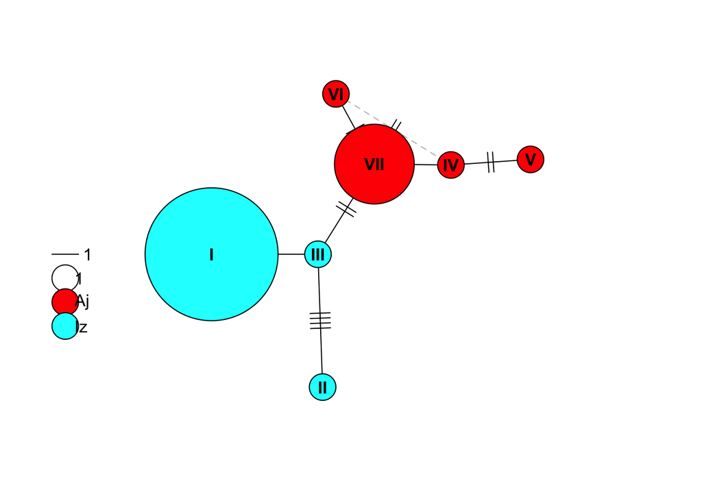

```r
plot(hnotu14, size=attr(hnotu14,"freq"), pie=hfotu14, legend=c(-10,0))
```

Repeat with other OTUs | Se repite con otras OTUs

```
## [1] "results for OTU1.fasta"
##
## Haplotypes extracted from: OTUi
##
##     Number of haplotypes: 3
##          Sequence length: 729
##
## Haplotype labels and frequencies:
##
##   I  II III
##   3   1   1
##      To
## [1,]  3
## [2,]  1
## [3,]  1
```

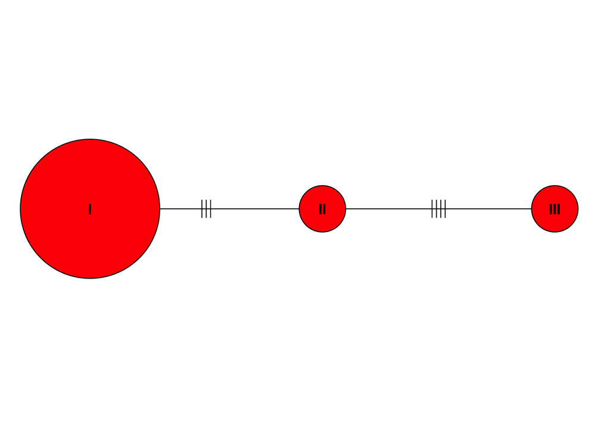

```
## [1] "results for OTU10.fasta"
##
## Haplotypes extracted from: OTUi
##
##     Number of haplotypes: 5
##          Sequence length: 775
##
## Haplotype labels and frequencies:
##
##   I  II III  IV   V
##   1   3   1  13   1
##      Bl To
## [1,]  1  0
## [2,]  3  0
## [3,]  1  0
## [4,]  0 13
## [5,]  0  1
```

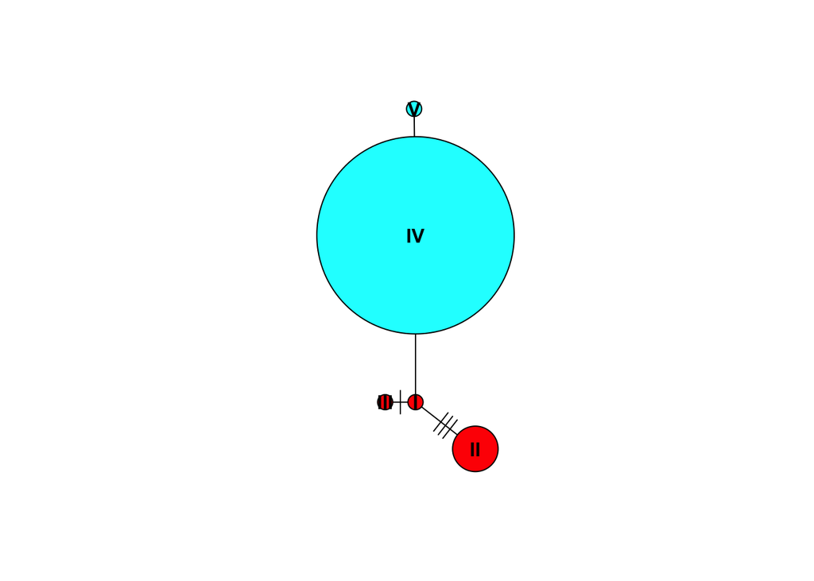

```
## [1] "results for OTU11_2.fasta"
##
## Haplotypes extracted from: OTUi
##
##     Number of haplotypes: 9
##          Sequence length: 775
##
## Haplotype labels and frequencies:
##
##    I   II  III   IV    V   VI  VII VIII   IX
##    6    7    1    2    1    2    1    1    1
##       _1 _2
##  [1,]  6  0
##  [2,]  0  7
##  [3,]  0  1
##  [4,]  0  2
##  [5,]  0  1
##  [6,]  0  2
##  [7,]  0  1
##  [8,]  0  1
##  [9,]  0  1
```

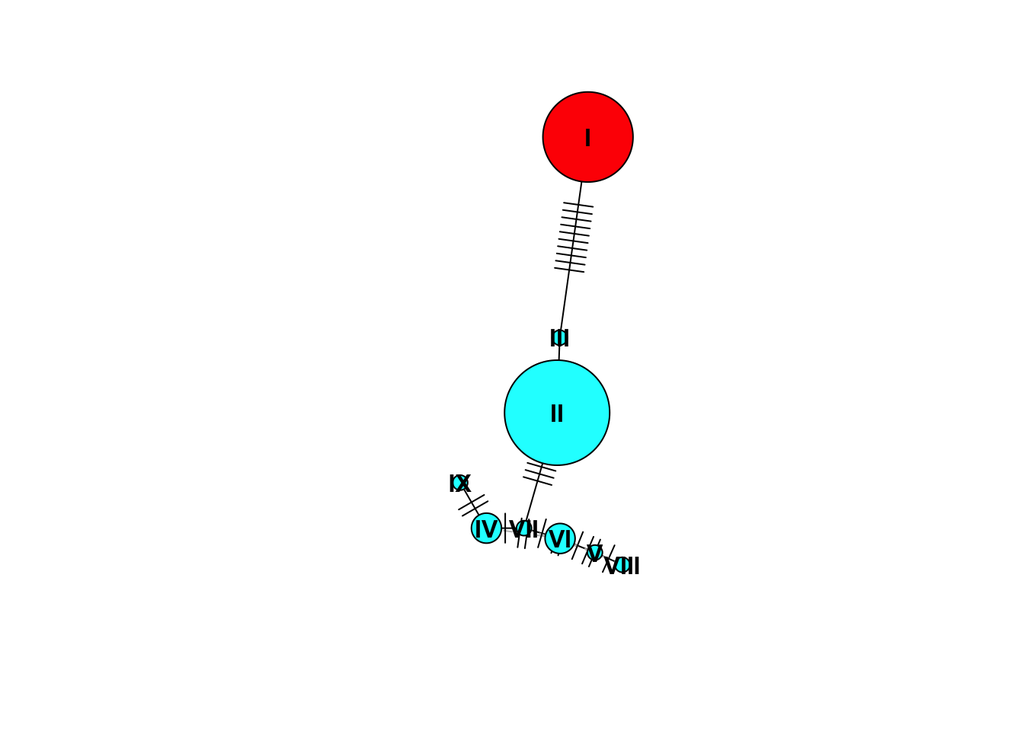

```
## [1] "results for OTU11.fasta"
##
## Haplotypes extracted from: OTUi
##
##     Number of haplotypes: 9
##          Sequence length: 775
##
## Haplotype labels and frequencies:
##
##    I   II  III   IV    V   VI  VII VIII   IX
##    6    7    1    2    1    2    1    1    1
##       Iz Ma Pe
##  [1,]  6  0  0
##  [2,]  0  7  0
##  [3,]  0  1  0
##  [4,]  0  0  2
##  [5,]  0  0  1
##  [6,]  0  0  2
##  [7,]  0  0  1
##  [8,]  0  0  1
##  [9,]  0  0  1
```

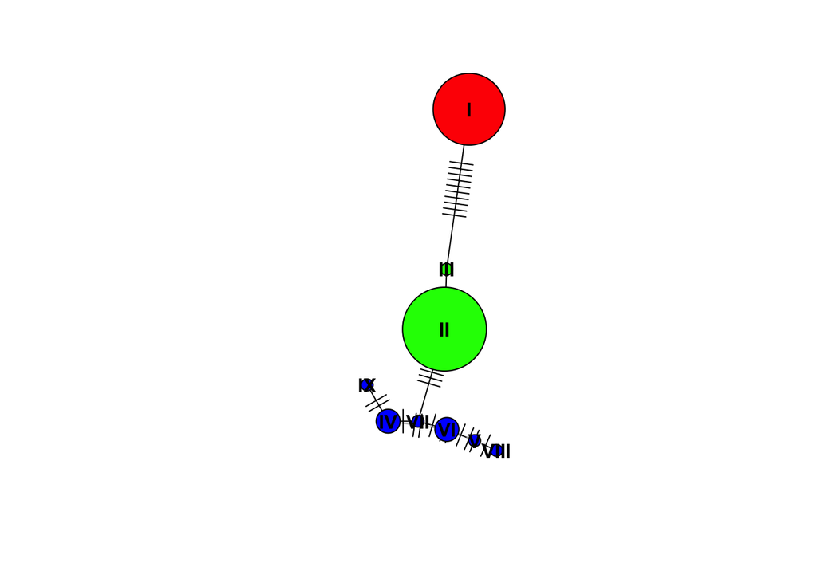

```
## [1] "results for OTU12.fasta"
##
## Haplotypes extracted from: OTUi
##
##     Number of haplotypes: 1
##          Sequence length: 599
##
## Haplotype labels and frequencies:
##
## I
## 2
##      Aj
## [1,]  2
## [1] "results for OTU13.fasta"
##
## Haplotypes extracted from: OTUi
##
##     Number of haplotypes: 1
##          Sequence length: 563
##
## Haplotype labels and frequencies:
##
##  I
## 11
##      Aj
## [1,] 11
## [1] "results for OTU14.fasta"
##
## Haplotypes extracted from: OTUi
##
##     Number of haplotypes: 7
##          Sequence length: 563
##
## Haplotype labels and frequencies:
##
##   I  II III  IV   V  VI VII
##   5   1   1   1   1   1   3
##      Aj Iz
## [1,]  0  5
## [2,]  0  1
## [3,]  0  1
## [4,]  1  0
## [5,]  1  0
## [6,]  1  0
## [7,]  3  0
```

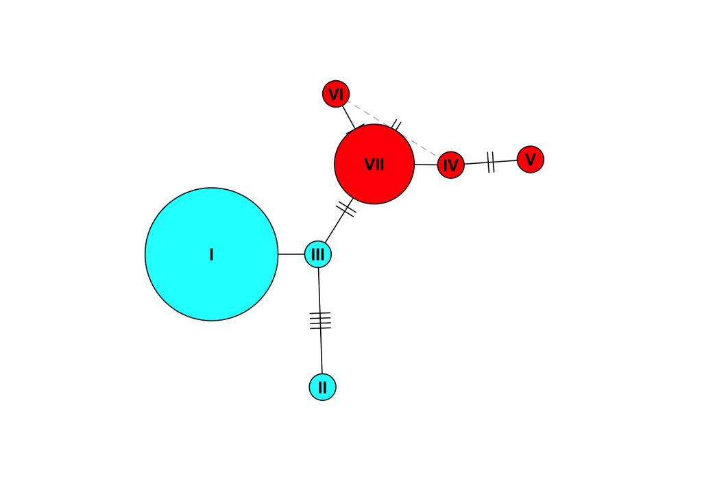

```
## [1] "results for OTU15.fasta"
##
## Haplotypes extracted from: OTUi
##
##     Number of haplotypes: 10
##          Sequence length: 563
##
## Haplotype labels and frequencies:
##
##    I   II  III   IV    V   VI  VII VIII   IX    X
##    3    1    4    1    1    3    1    1    1    2
##       Aj Pe
##  [1,]  1  2
##  [2,]  0  1
##  [3,]  2  2
##  [4,]  1  0
##  [5,]  0  1
##  [6,]  1  2
##  [7,]  1  0
##  [8,]  1  0
##  [9,]  1  0
## [10,]  0  2
```

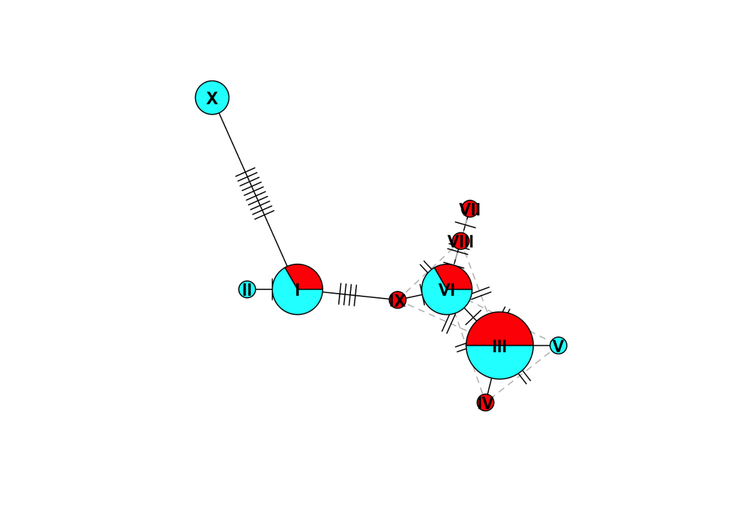

```
## [1] "results for OTU16.fasta"
##
## Haplotypes extracted from: OTUi
##
##     Number of haplotypes: 2
##          Sequence length: 563
##
## Haplotype labels and frequencies:
##
##  I II
##  1  1
##      Bl Pe
## [1,]  1  0
## [2,]  0  1
```

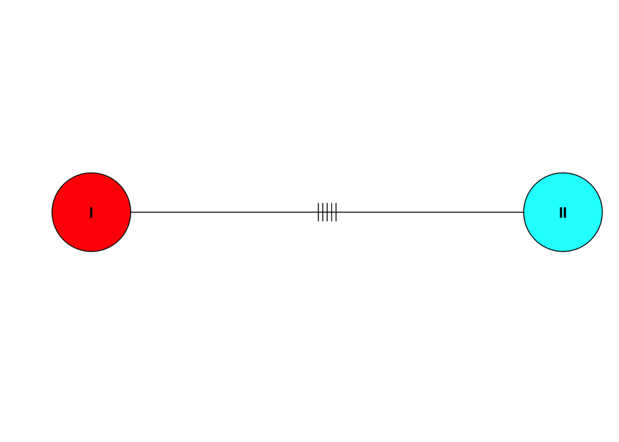

```
## [1] "results for OTU17.fasta"
##
## Haplotypes extracted from: OTUi
##
##     Number of haplotypes: 2
##          Sequence length: 563
##
## Haplotype labels and frequencies:
##
##  I II
##  5  1
##      Pe
## [1,]  5
## [2,]  1
```

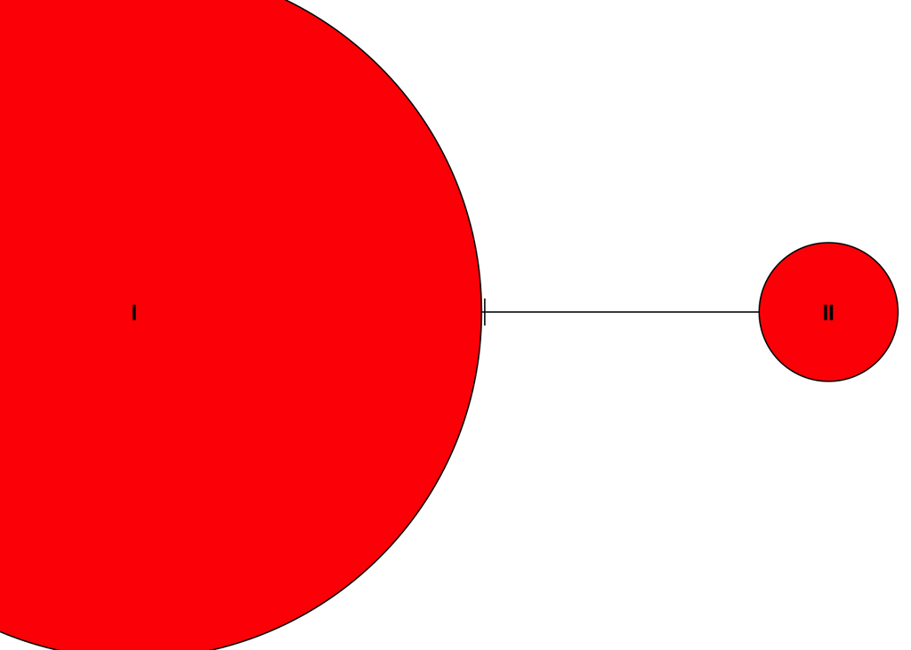

```
## [1] "results for OTU18.fasta"
##
## Haplotypes extracted from: OTUi
##
##     Number of haplotypes: 5
##          Sequence length: 563
##
## Haplotype labels and frequencies:
##
##   I  II III  IV   V
##   1   9   1   1   2
##      Aj Bl Ma To
## [1,]  0  1  0  0
## [2,]  0  0  0  9
## [3,]  0  0  1  0
## [4,]  0  0  1  0
## [5,]  2  0  0  0
```

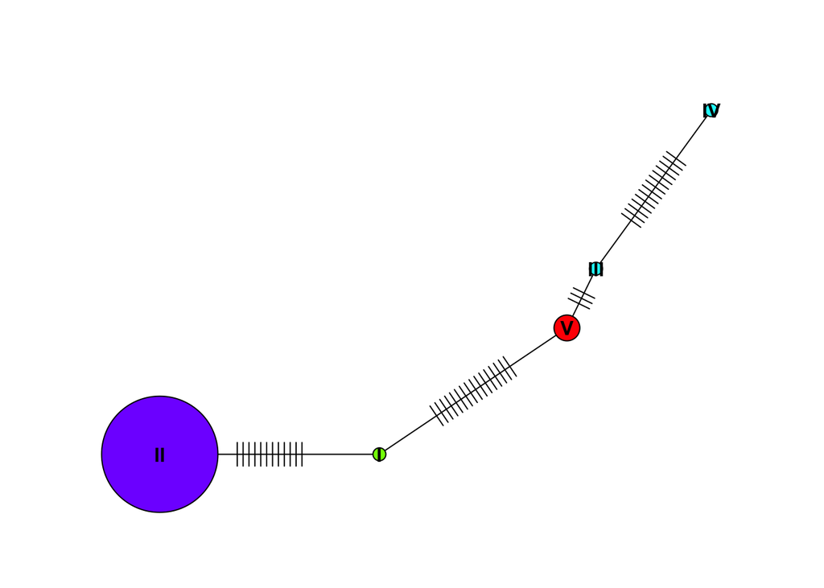

```
## [1] "results for OTU19.fasta"
##
## Haplotypes extracted from: OTUi
##
##     Number of haplotypes: 5
##          Sequence length: 563
##
## Haplotype labels and frequencies:
##
##   I  II III  IV   V
##   1   1   1   1   1
##      Ma Pe
## [1,]  0  1
## [2,]  0  1
## [3,]  0  1
## [4,]  0  1
## [5,]  1  0
```

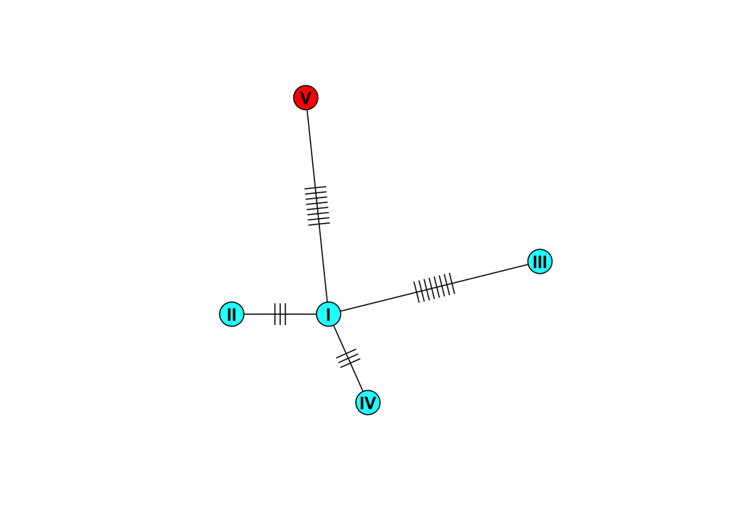

```
## [1] "results for OTU2.fasta"
##
## Haplotypes extracted from: OTUi
##
##     Number of haplotypes: 3
##          Sequence length: 729
##
## Haplotype labels and frequencies:
##
##   I  II III
##   1   1   2
##      Ma
## [1,]  1
## [2,]  1
## [3,]  2
```

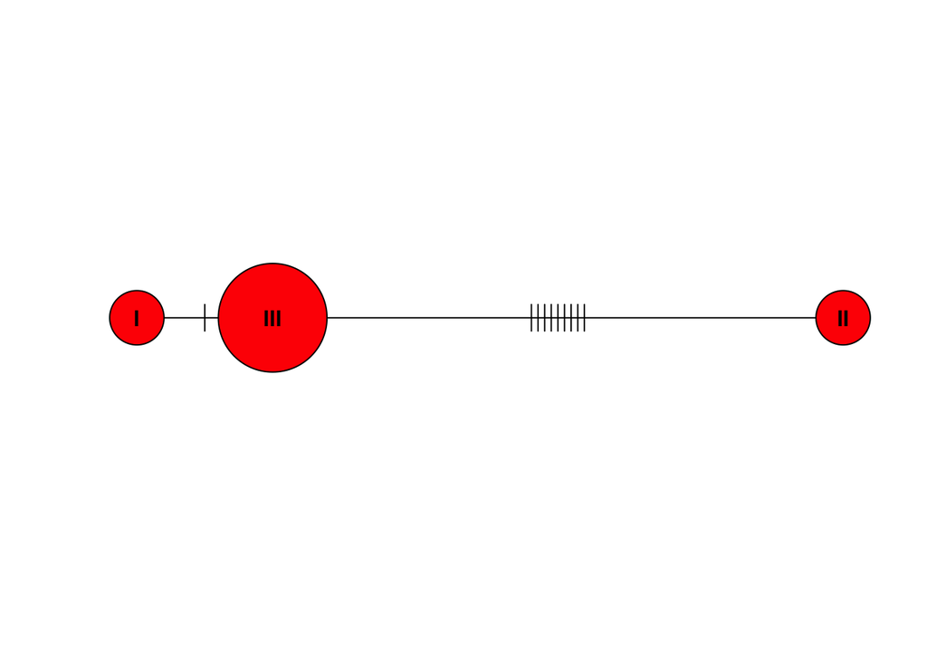

```
## [1] "results for OTU20.fasta"
##
## Haplotypes extracted from: OTUi
##
##     Number of haplotypes: 5
##          Sequence length: 563
##
## Haplotype labels and frequencies:
##
##   I  II III  IV   V
##   2   4   1   3   1
##      Aj Bl Iz To
## [1,]  0  2  0  0
## [2,]  0  1  3  0
## [3,]  1  0  0  0
## [4,]  0  0  0  3
## [5,]  0  0  0  1
```

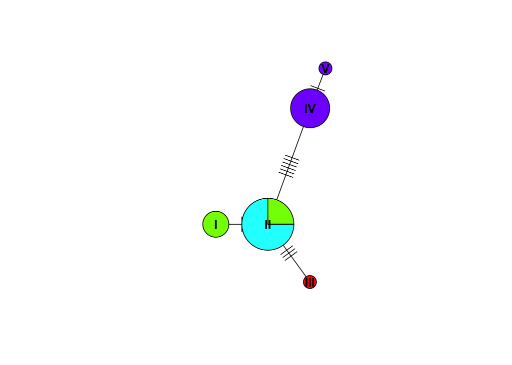

```
## [1] "results for OTU21.fasta"
##
## Haplotypes extracted from: OTUi
##
##     Number of haplotypes: 3
##          Sequence length: 563
##
## Haplotype labels and frequencies:
##
##   I  II III
##   1   1   1
##      Iz To
## [1,]  0  1
## [2,]  0  1
## [3,]  1  0
```

[12 more figures not shown]

```
## [1] "results for OTU9.fasta"
##
## Haplotypes extracted from: OTUi
##
##     Number of haplotypes: 1
##          Sequence length: 750
##
## Haplotype labels and frequencies:
##
## I
## 1
##      Ma
## [1,]  1
```

```r
OTUS<-grep("OTU[1-9]", list.files("sequences_fasta"), value=TRUE)

for (i in 1:length(OTUS)) {

OTU<-OTUS[i]

print(paste("results for", OTU))

# Read and explore haplotypes
OTUi<-read.dna(paste0("sequences_fasta/",OTU), format="fasta")
haplosOTUi<-haplotype(OTUi)
print(haplosOTUi)

# get pop information
pops<-substr(labels(OTUi), 1,2)
pops<-as.factor(pops)

# Estimate haplotype freq by pop
hfOTUi<-haploFreq(OTUi, fac=pops)
print(hfOTUi)

# If there is more than one haplotype:
if (dim(haplosOTUi)[1]>1){
# build haplo network
hnOTUi<-haploNet(haplosOTUi)
plot(hnOTUi, size=attr(hnOTUi,"freq"), pie=hfOTUi, legend=FALSE)
  }
}
```

### Beta diversity

First, read the csv file with the list of number of individuals per OTU in each mountain. | Primero, se lee el documento csv con la lista de individuos de cada OTU por montaña

```r
OTUs <- read.csv("OTUs.csv")
row.names(OTUs)<-OTUs$OTU
OTUs<-OTUs[1:44,2:8] #delete column OTU, not needed.
OTUs
```

|  | An | Bl | To | Aj | Iz | Ma | Pe |
| --- | --- | --- | --- | --- | --- | --- | --- |
| 1 | 0 | 0 | 5 | 0 | 0 | 0 | 0 |
| 2 | 0 | 0 | 0 | 0 | 0 | 4 | 0 |
| 3 | 0 | 0 | 0 | 0 | 10 | 3 | 1 |
| 4 | 0 | 0 | 0 | 0 | 2 | 0 | 0 |
| 5 | 0 | 0 | 0 | 0 | 0 | 0 | 2 |
| 6 | 0 | 0 | 0 | 1 | 0 | 0 | 0 |
| 7 | 0 | 0 | 0 | 0 | 0 | 1 | 0 |
| 8 | 0 | 4 | 5 | 1 | 0 | 4 | 0 |
| 10 | 0 | 5 | 14 | 0 | 0 | 0 | 0 |
| 11 | 0 | 0 | 0 | 0 | 6 | 8 | 8 |

[output cut: 34 more lines]

Convert the csv file to matrix and tranpose the matrix so that otus are in columns and sites in rows. Then, calculate a presence-absence matrix, where each cell will be first converted to T if there are one or more individuals in a site, and F if there are 0 individuals. Then, T are transformed to 1, and F to 0. | Se traspone la matriz para que las especies sean las columnas (variables) y los sitios los renglones. Después, se calcula una matriz de presencia-ausencia, en donde cada celda es transformada en T si hay al menos un individuo o más en el sitio, y F si hay 0 individuos. Después se transforman las T en 1 y las F en 0.

```r
OTUs.PA<-OTUs>0 #T and F instead of number of individuals
mode(OTUs.PA)<-"integer" # T=1 y F=0
head(OTUs)
```

|  | An | Bl | To | Aj | Iz | Ma | Pe |
| --- | --- | --- | --- | --- | --- | --- | --- |
| 1 | 0 | 0 | 5 | 0 | 0 | 0 | 0 |
| 2 | 0 | 0 | 0 | 0 | 0 | 4 | 0 |
| 3 | 0 | 0 | 0 | 0 | 10 | 3 | 1 |
| 4 | 0 | 0 | 0 | 0 | 2 | 0 | 0 |
| 5 | 0 | 0 | 0 | 0 | 0 | 0 | 2 |
| 6 | 0 | 0 | 0 | 1 | 0 | 0 | 0 |

```r
OTUs.PA
```

```
##    An Bl To Aj Iz Ma Pe
## 1   0  0  1  0  0  0  0
## 2   0  0  0  0  0  1  0
## 3   0  0  0  0  1  1  1
## 4   0  0  0  0  1  0  0
## 5   0  0  0  0  0  0  1
## 6   0  0  0  1  0  0  0
## 7   0  0  0  0  0  1  0
## 8   0  1  1  1  0  1  0
## 10  0  1  1  0  0  0  0
## 11  0  0  0  0  1  1  1
## 12  0  0  0  1  0  0  0
## 13  0  0  0  1  0  0  0
## 14  0  0  0  1  1  0  0
## 15  0  0  0  1  0  0  1
```

[output cut: 30 more lines]

```r
colSums(OTUs.PA)
```

```
## An Bl To Aj Iz Ma Pe
##  5  9 10 19  9  7 10
```

Calculate a matrix distance using the function betadiver. If you want o take a look at all indeces in this function, run betadiver(HELP=T). Option 10 and 11 are similarity indeces, the rest are distance indeces. Make a cluster and a PCoA to visualize the results. | Se calcula una matriz de distancia usando la función betadiver. Si se quiere ver todas las opciones de índices que tiene esta función, se puede hacer con betadiver(HELP=T). Las opciones 10 y 11 son índices de similitud, todos los demás son índices de distancia. Para visualizar los resultados, se hace un cluster y un PCoA.

```r
OTUs<-as.matrix(OTUs) #La convertimos en matriz
OTUs<-t(OTUs) #Trasponemos la matriz para que las especies sean las columnas (variables) y los sitios los renglones.
OTUs.PA<-OTUs>0 #T and F instead of number of individuals
OTUsdist<-betadiver(OTUs.PA,method=1)
OTUsdist # print pairwise betadiv
```

```
##           An        Bl        To        Aj        Iz        Ma
## Bl 0.8571429
## To 1.0000000 0.4736842
## Aj 1.0000000 0.7857143 0.7931034
## Iz 1.0000000 0.7777778 0.6842105 0.7142857
## Ma 1.0000000 0.7500000 0.7647059 0.8461538 0.7500000
## Pe 1.0000000 0.8947368 1.0000000 0.8620690 0.7894737 0.6470588
```

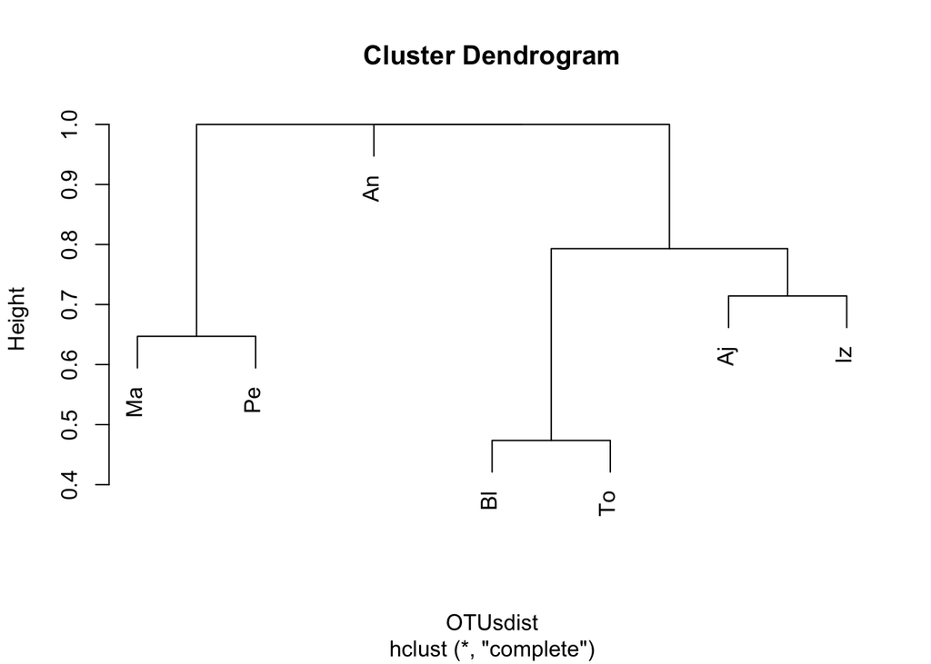

```r
cluster<-hclust(OTUsdist)
plot(cluster)
```

```r
PCoA<-dudi.pco(sqrt(OTUsdist),scannf=F)
summary(PCoA)
```

```
## Class: pco dudi
## Call: dudi.pco(d = sqrt(OTUsdist), scannf = F)
##
## Total inertia: 0.3549
##
## Eigenvalues:
##     Ax1     Ax2     Ax3     Ax4     Ax5
## 0.08451 0.08207 0.06412 0.05028 0.04298
##
## Projected inertia (%):
##     Ax1     Ax2     Ax3     Ax4     Ax5
##   23.81   23.12   18.07   14.17   12.11
##
## Cumulative projected inertia (%):
##     Ax1   Ax1:2   Ax1:3   Ax1:4   Ax1:5
##   23.81   46.94   65.00   79.17   91.28
##
## (Only 5 dimensions (out of 6) are shown)
```

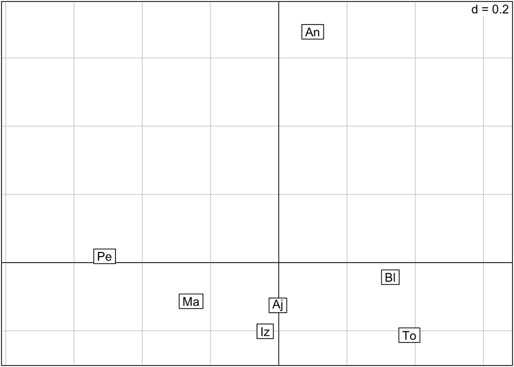

```r
scatter(PCoA, xax=1, yax=2, posieig="none")
```

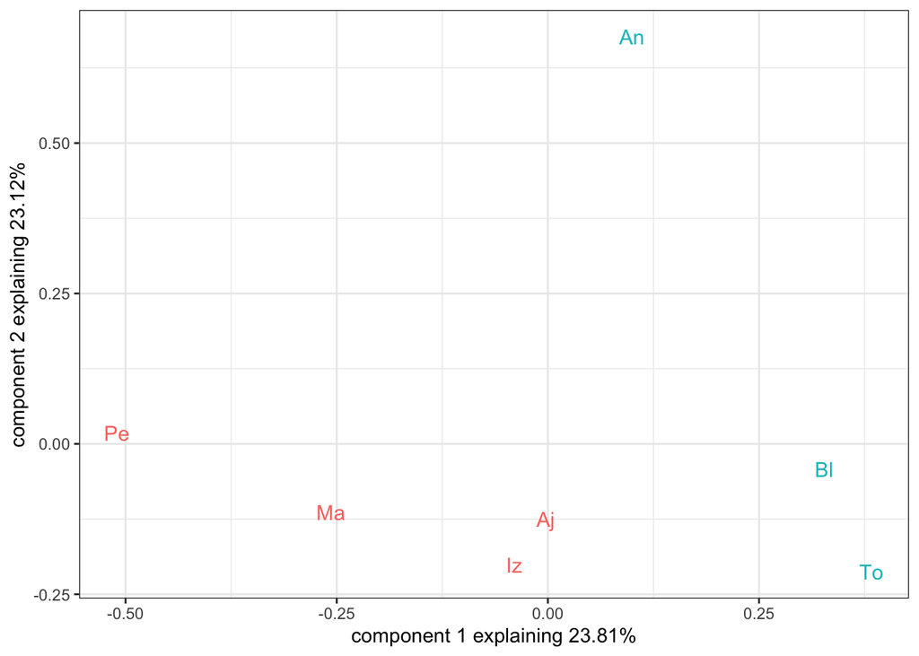

```r
### Nicer plot of PCA for paper
library(ggplot2)
# add West/East category for color plotting
tab<-PCoA$tab
tab$WE<-c("West", "West", "West", "East", "East", "East", "East")

ggplot(data= tab, aes(x=A1, y=A2, label=rownames(tab))) + geom_text(size=4, aes(colour = factor(WE))) +
      ylab(paste0("component 2 explaining ",
                  round(PCoA$eig[2]/sum(PCoA$eig)*100, 2), "%")) +
      xlab(paste0("component 1 explaining ",
                  round(PCoA$eig[1]/sum(PCoA$eig)*100, 2), "%")) +
      theme_bw() + theme(legend.position="none")
```